# Twitter hashtag analysis: #birdoftheyear OR #boty

Ben Anderson (`@dataknut`)

Last run at: 2018-10-04 12:46:01

# 1 Terms of re-use

## 1.1 License

[CC-BY-SA](https://creativecommons.org/licenses/by-sa/4.0/) unless otherwise noted.

## 1.2 Citation

- Anderson, B (2018) *Twitter hashtag analysis: #birdoftheyear OR #boty*. Downloaded from: https://dataknut.github.io/hashTagR//docs/birdOfTheYear2018.html.

# 2 Purpose

To extract and visualise tweets and re-tweets of *#birdoftheyear OR #boty* (see https://twitter.com/hashtag/birdoftheyear and the [Forest & Bird voting site](https://www.birdoftheyear.org.nz/)).

Borrowing extensively from https://github.com/mkearney/rtweet

The analysis used `rtweet` to ask the Twitter search API to extract ‘all’ tweets containing the *#birdoftheyear OR #boty* hashtags in the ‘[recent](https://developer.twitter.com/en/docs/tweets/search/api-reference/get-search-tweets)’ twitterVerse.

It is therefore possible that not quite all tweets have been extracted although it seems likely that we have captured most recent `human` tweeting which was the main intention. Future work should instead use the Twitter [streaming API](https://dev.twitter.com/streaming/overview).

```
## [1] "Found 14 files matching #birdoftheyear OR #boty in ~/Data/twitter/"
```

The data has:

- 7,244 tweets (including 441 quotes and 5,085 re-tweets)
- from 3,218 tweeters
- between 2018-09-18 14:43:25 and 2018-10-03 23:31:34 (UTC).

# 3 Analysis

## 3.1 Tweets and Tweeters over time

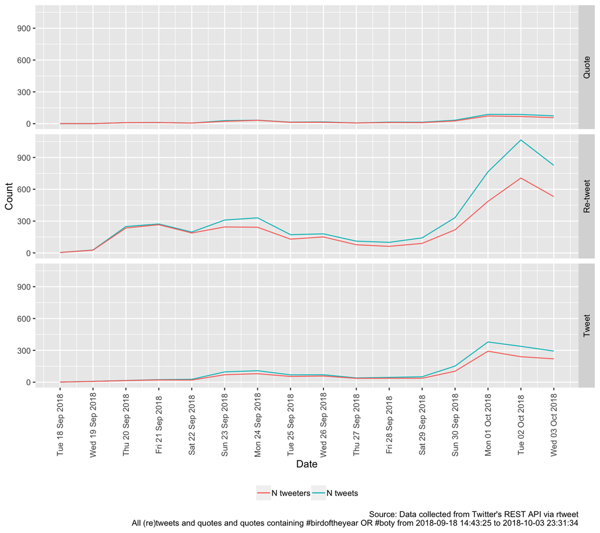

Figure 3.1: Number of tweets and tweeters

If you are in New Zealand and you are wondering why there are no tweets `today` (2018-10-04) the answer is that twitter data (and these plots) are working in UTC and (y)our `today` hasn’t started yet in UTC - but don’t worry, all the tweets are here. It’s just our old friend the timezone… :-)

## 3.2 Who’s tweeting?

Next we’ll try by screen name.

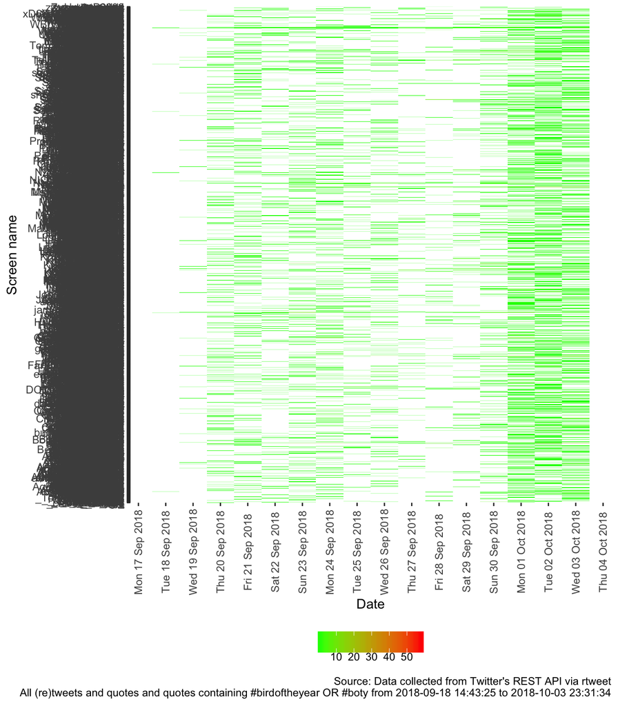

Figure 3.2: N tweets per day by screen name

Figure 3.2 is a really bad visualisation of all tweeters tweeting over time. Each row of pixels is a tweeter (the names are probably illegible) and a green dot indicates a few tweets in the given day while a red dot indicates a lot of tweets.

So let’s re-do that for the top 50 tweeters so we can see their tweetStreaks (tm)…

Top tweeters:

Table 3.1: Top 15 tweeters (all days)

| screen_name | nTweets |
| --- | --- |
| birdoftheyear | 254 |
| Forest_and_Bird | 100 |
| testeeves | 98 |
| vote4kaki | 74 |
| NatForsdick | 68 |
| coolbiRdpics | 66 |
| mifflangstone | 55 |
| jackcraw57 | 49 |
| thebushline | 42 |
| freshwaterfelix | 39 |
| kiwilullaby | 39 |
| newzealandbirds | 35 |
| hugobrown | 33 |
| kimi_collins | 32 |
| 64by4 | 32 |

And their tweetStreaks are shown in 3.3…

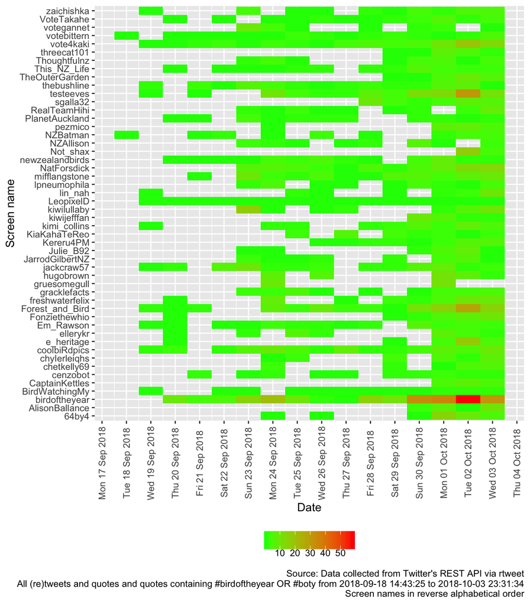

Figure 3.3: N tweets per day minutes by screen name (top 50, reverse alphabetical)

Any twitterBots…?

## 3.3 Which birds are mentioned the most (by hashtag)

This is very quick and dirty but… Table 3.2 shows the total count of each #hashtag. Note that I have tried to [de-macron](https://kupu.maori.nz/about/macrons-keyboard-setup) the vowels so that kakī == kaki (for example) but it is currently not working.

Table 3.2: Top 20 hashtags in tweets containing #birdoftheyear or #boty

| htClean | ba_tweetType | count |
| --- | --- | --- |
| birdoftheyear | Re-tweet | 2668 |
| birdoftheyear | Tweet | 1617 |
| takayay | Re-tweet | 506 |
| birdoftheyear | Quote | 433 |
| kakī | Re-tweet | 164 |
| teamkakī | Re-tweet | 163 |
| boty | Re-tweet | 159 |
| dammitgannet | Re-tweet | 138 |
| boty | Tweet | 121 |
| kereru | Re-tweet | 119 |
| vote4kakī | Re-tweet | 81 |
| dammitgannet | Tweet | 79 |
| voteruru | Re-tweet | 75 |
| aotearoa | Re-tweet | 65 |
| teamrockhopper | Tweet | 63 |
| greatkererucount | Re-tweet | 62 |
| nativebird | Re-tweet | 62 |
| woodpidgeon | Re-tweet | 61 |
| teamkakī | Tweet | 58 |
| votebittern | Tweet | 52 |

Figure 3.4 plots the daily occurence of these hashtags after removing variants of `#birdOfTheYear` and `#boty` and selecting only those which have more than 10 mentions on any day. Tweets mentioning birds without using a `#<birdName>` hashtag will not show up and we still have the kakī != kaki issue so this is a *really* imperfect measure. For clarity we have not separated tweets from re-tweets. #YMMV.

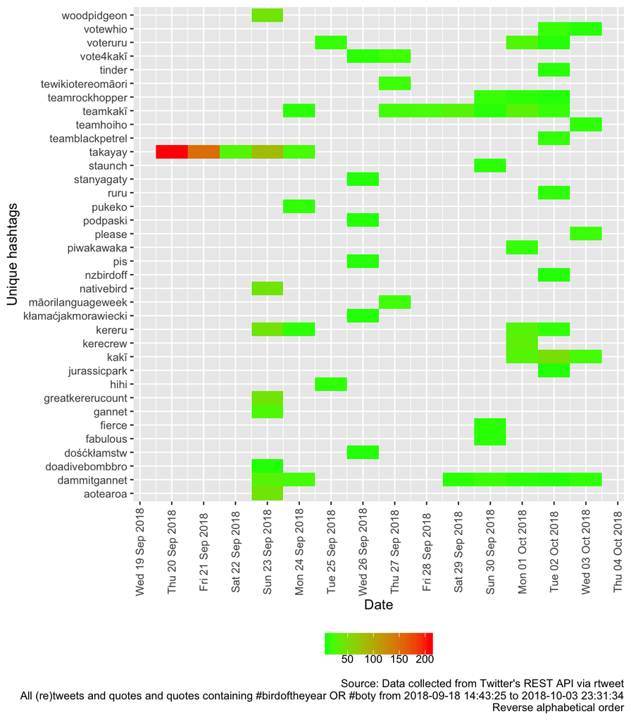

Figure 3.4: Most mentioned #hashtags per day

# 4 About

Analysis completed in 44.574 seconds ( 0.74 minutes) using knitr in [RStudio](http://www.rstudio.com) with R version 3.5.1 (2018-07-02) running on x86_64-apple-darwin15.6.0.

A special mention must go to `https://github.com/mkearney/rtweet` (Kearney 2018) for the twitter API interaction functions.

Other R packages used:

- base R - for the basics (R Core Team 2016)
- data.table - for fast (big) data handling (Dowle et al. 2015)
- ggplot2 - for slick graphs (Wickham 2009)
- readr - for nice data loading (Wickham, Hester, and Francois 2016)
- reshape2 - wide to long (Wickham 2007)
- rtweet - twitter API search (Kearney 2018)
- knitr, bookdown & kableExtra - to create this document (Xie 2016b,Xie (2016a), Zhu (2018))

# References

Dowle, M, A Srinivasan, T Short, S Lianoglou with contributions from R Saporta, and E Antonyan. 2015. *Data.table: Extension of Data.frame*. https://CRAN.R-project.org/package=data.table.

Kearney, Michael W. 2018. *Rtweet: Collecting Twitter Data*. https://cran.r-project.org/package=rtweet.

R Core Team. 2016. *R: A Language and Environment for Statistical Computing*. Vienna, Austria: R Foundation for Statistical Computing. https://www.R-project.org/.

Wickham, Hadley. 2007. “Reshaping Data with the reshape Package.” *Journal of Statistical Software* 21 (12): 1–20. http://www.jstatsoft.org/v21/i12/.

———. 2009. *Ggplot2: Elegant Graphics for Data Analysis*. Springer-Verlag New York. http://ggplot2.org.

Wickham, Hadley, Jim Hester, and Romain Francois. 2016. *Readr: Read Tabular Data*. https://CRAN.R-project.org/package=readr.

Xie, Yihui. 2016a. *Bookdown: Authoring Books and Technical Documents with R Markdown*. Boca Raton, Florida: Chapman; Hall/CRC. https://github.com/rstudio/bookdown.

———. 2016b. *Knitr: A General-Purpose Package for Dynamic Report Generation in R*. https://CRAN.R-project.org/package=knitr.

Zhu, Hao. 2018. *KableExtra: Construct Complex Table with ’Kable’ and Pipe Syntax*. https://CRAN.R-project.org/package=kableExtra.